# Report for Job [KEY:Protein_Protein_Cor__Pearson__No]

WGIA

2024-08-13 20:11:20

**You can bookmark this page to access the results later, or [download the report](http://gpu.zjwm.cc:88/wgia/public/job/Protein_Protein_Cor__Pearson__No/report.html) locally.**

*Results will be stored for 30 days.*

> WGIA is an open-access web application designed for genome-wide interaction analysis. Leveraging GPU parallel technologies, it significantly enhances computational efficiency. You can upload the SNP, DNA methylation, gene expression, or other biological data, and WGIA generates a comprehensive report within a short timeframe.

# 1. Datasets information

## 1.1 marker information

**There are total 91 (Protein) used for interaction analysis.**

- In order to provide the fullest results as possible, WGIA provided interaction for all the Protein uploaded, with out quality control for the data.
- Note: If needed, some basic information about Protein can be used to perform quality control before uploaded the datasets, such as the missing rate.

## 1.2 sample information

**There are total of 50 samples used for interaction calculation.** **Note: There are no other sample information be used.**

# 2. Interaction analysis results

## 2.1 Correlation distribution

**The WGIA performed a total of 4,095 calculations between 91 Protein for this job, encompassing correlation coefficients (Pearson) among all possible Protein-Protein pairs. The results are displayed below.**

> **PPI:** PPI (Protein-Protein Interaction) analysis studies the interactions between different Proteins to understand the functional networks within the cell.  
> **Pearson:** Pearson correlation measures the linear relationship between two continuous variables, providing a coefficient that ranges from -1 to 1.

**The plot below displays the distribution of the Correlation of all the 4,095 Protein-Protein pairs (markers) in the dataset.**

- These results can be downloaded here Cor_distribution.txt.

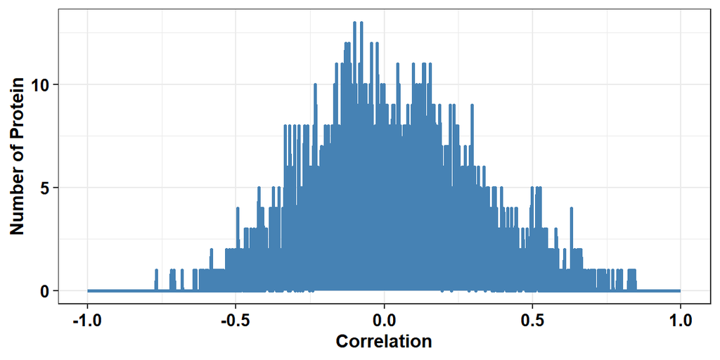

- A more rough distribution of intervals is as follows:

[output not shown]

## 2.2 Correlation distribution metrics

**Some basic information about the distribution is provided in the table below, including mean value, variance, standard deviation, skewness, kurtosis, median_value, lower quartile, upper quartile, interquartile range.**

- **Mean value**: The average value of the data set.
- **Variance**: A measure of how much the data points differ from the mean.
- **Standard deviation**: The square root of the variance, indicating the spread of the data.
- **Skewness**: A measure of the asymmetry of the data distribution.
- **Kurtosis**: A measure of the “tailedness” of the data distribution.
- **Median value**: The middle value that separates the higher half from the lower half of the data set.
- **Lower quartile (Q1)**: The median of the lower half of the data set (25th percentile).
- **Upper quartile (Q3)**: The median of the upper half of the data set (75th percentile).
- **Interquartile range (IQR)**: The range between the lower quartile and the upper quartile (Q3 - Q1), measuring the spread of the middle 50% of the data.
- These results can be downloaded here Cor_distribution.txt. The last 9 line of the file are the metric values of the distribution.

|  | metrics | value |
| --- | --- | --- |
| 1 | mean value | 0.022040 |
| 2 | variance | 0.063083 |
| 3 | standard deviation | 0.251164 |
| 4 | skewness | 0.003440 |
| 5 | kurtosis | 0.011676 |
| 6 | lower quartile | -0.151893 |
| 7 | median_value | 0.008278 |
| 8 | upper quartile | 0.183542 |
| 9 | interquartile range | 0.335435 |

- These results can be downloaded here Cor.txt.

  | Marker1 | Marker2 | Correlation | Lower | Upper | t-statistic |
  | --- | --- | --- | --- | --- | --- |
  | ABHD14B | ABHD15 | 0.540393 | 0.308435 | 0.711693 | 4.449605 |
  | ABHD14B | ABHD2 | -0.270238 | -0.510211 | 0.008775 | -1.944612 |
  | ABHD14B | ABHD3 | -0.416111 | -0.622377 | -0.155805 | -3.170415 |
  | ABHD14B | ABHD4 | 0.090035 | -0.193158 | 0.359381 | 0.626328 |
  | ABHD14B | ABHD5 | -0.274161 | -0.513339 | 0.004538 | -1.975125 |
  | ABHD14B | ABHD6 | 0.162901 | -0.120935 | 0.422113 | 1.143892 |

- If you need the full results, Please perform the interaction analysis with our local software WGIA.exe